# Assignment 5 - K-means

Author

Hari Marasini

# 1 Goal of this assignment

The goal of this assignment is for you to **explore the k-means algorithm** learned in class.

In specific, you will be asked to:  
- Use a different number of k than what we did in class,  
- Validate the results of the new model, and  
- Compare your results with those found in class

# 2 Instructions

You will first need to watch (and code along with) the following k-means video:

- k-means lab: https://youtu.be/GFgMp5tYiMU?si=CI0E-2r-cYZLGVL1 (start from beginning of video, watch till the 01:10)
- The partial script for the video above is in our GitHub repository, 04-classcode, **02-24_multivar_kmeans_partial.qmd**. Move the script mentioned above into the `code` subfolder of your `06_multivar` project

**AFTER watching the video and developing the code in class**, then start working on this HW assignment (instructions below): - Move this script into the `code` subfolder of your `06_multivar` project  
- On this script, fill your name under the `title` section of the YAML  
- Go back to the class k-means script, choose a different number of k than what we did in class, and run it.

# 3 Questions

## 3.1 1. What number of k did you select? Why?

```r
library(tidyverse)
library(ggcorrplot)
library(broom)
library(car)
library(factoextra)
library(ggpmisc)

weather <- read_csv("../data/weather_monthsum.csv")

#selecting numerical variables only for k-means
weather_n <- weather %>%
  dplyr::select(-c(year:strength_gtex))


# normalizing the data
weather_norm  <- weather_n %>%
  mutate(across(everything(), ~scale(.x)))
```

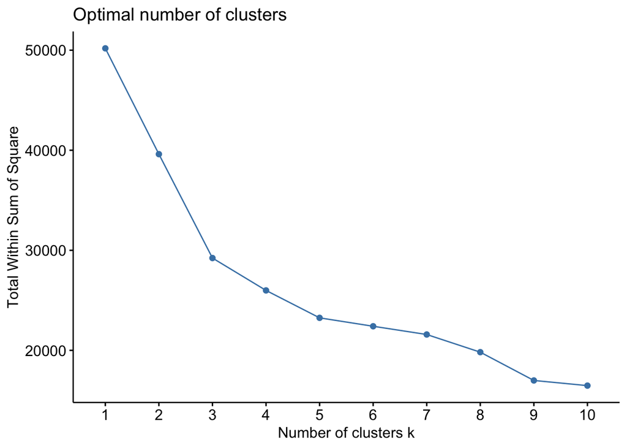

```r
# Total error x k
fviz_nbclust(weather_norm,
             method = "wss",   #within sum of squares methods
             k.max = 10,
             FUNcluster = kmeans      #FUNction of clustering
             )
```

**I chose k = 5. Because, the line graph plotted using “wss” method seems reasonably elbowed at 5th cluster.**

## 3.2 2. How many observations are there in each cluster?

```r
mod_km5 <- kmeans(weather_norm,
                  centers = 5,
                  nstart = 10
                  )
```

```r
weather %>%
  mutate(cluster = mod_km5$cluster) %>%
  group_by(cluster) %>%
  tally()
```

```
# A tibble: 5 × 2
  cluster     n
    <int> <int>
1       1   182
2       2    56
3       3   236
4       4   208
5       5    16
```

**For clusters 1, 2, 3, 4 and 5, there are 182, 56, 236, 208 and 16 observations.**

## 3.3 3. Using the `fviz_cluster()` function, import here the original plot with k=4 did in class, and the new plot with the number of k you selected for this exercise. How do they visually compare? Which one seems to be a better choice, and why?

**Original plot with k = 4**

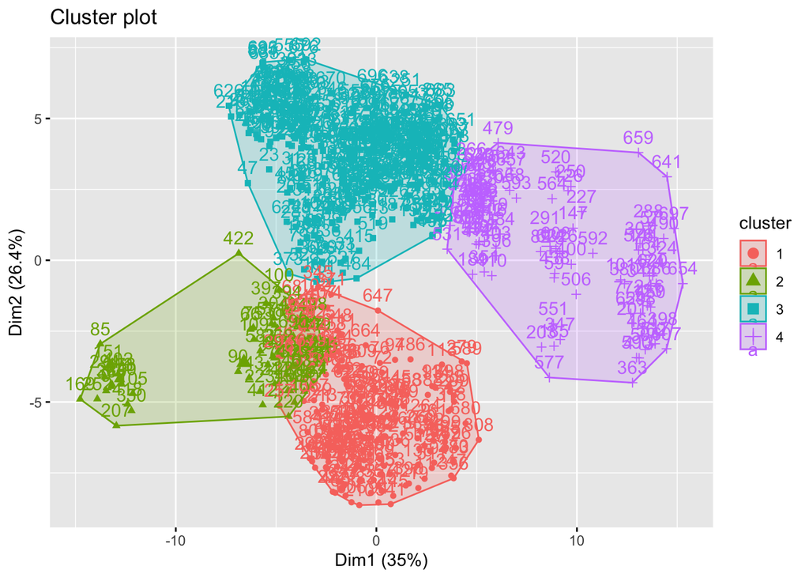

```r
mod_km4 <- kmeans(weather_norm,
                  centers = 4,
                  nstart = 10
                  )


fviz_cluster(mod_km4,
             data = weather_norm
             )
```

**New plot with k = 5**

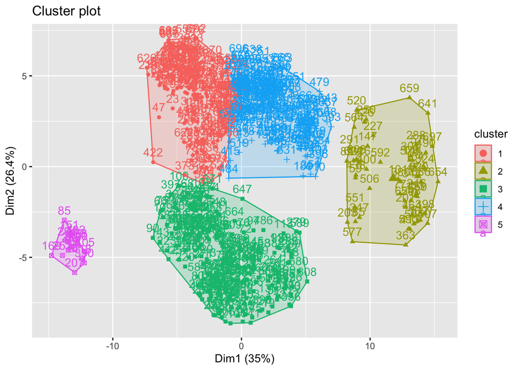

```r
fviz_cluster(mod_km5,
             data = weather_norm
             )
```

**Upon visual inspection, k = 5 seems to be better choice for me because the clusters have relatively less overlap and are more distinctly separated. In k = 4, two clusters (olive green and orange color) on bottom section of image, seem to be heavily overlapped without distinct clustering**

# 4 Submitting your work

Once you have developed all the code and answers, make sure to Render this quarto file.

**Notes on rendering**:

- Make sure to render your work and inspect how the final html look like.
- If it does not look professional for whatever reason, then fix the issue, re-render it, recheck.
- Only send me your work once your html file looks professional.
  - **DO NOT** delete the file’s heading levels (# and ##). They set up the proper heading 1 and 2 levels, and I use them to guide my grading.
  - If a given chunk is also outputting warnings or messages, inhibit this behavior by changing the chunk options `message` and `warning` to `FALSE` (I’ll demo this in a moment).
  - If, after rendered, 2 lines of text are connected and you wish to “break line” between them, add 2 extra spaces after the first one (I’lld demo this in a moment).

After rendering, an .html file will be created on your `code` folder.

Rename this file to `Assignment-05-kmeans-LASTNAME.html`.

For ex., mine would be `Assignment-05-kmeans-Bastos.html`.

Submit your work by uploading the **html** file to **eLC Assignment #5 - K-means** by Monday March 2nd 11:59 pm.